# Predicting Weight-Lifting Performance

Rudy

2015/02/22

## Introduction

This is an assignment for Johns Hopkins University’s *[Data Science Specialisation](https://www.coursera.org/specialization/jhudatascience/1)* course being run on Coursera.

It attempts to predict the performance of weight-lifting exercises using measurements from devices recording bodily position and acceleration. We’ve used bootstrap aggregated decision trees and achieved a high accuracy rate of 0.99 for both in-sample (using 10-fold cross-validation repeated three times) and estimated out-sample (using a hold-out sample) accuracies.

## Data

The data consists of 19622 observations and 160 variables. The data is available from Velloso *et al*, downloadable from http://groupware.les.inf.puc-rio.br/har. It is licensed under the *Creative Commons Attribution-ShareAlike license*.

Our first step is to clean as much of this data as we can. The data has two main problems:

- Missing values are inconsistently encoded as both NA and empty strings
- There are variables containing the meaningless value #DIV/0!.

Both of the above we will encode as NA values. The following function does this on vectors of values:

```r
clean.column <- function(col) {
    col[col == "" | col == "#DIV/0!"] <- NA
    as.numeric(col)
}
```

The data can then be read in and cleaned using the following function:

```r
library(dplyr)

read.data <- function() {
    # We want to remove the initial X variable, which is just a line number.
    data <- read.csv('data/pml-training.csv') %>% select(-X)

    # The first six variables are integers and factor variables
    front.matter <- data %>% select(1:6)

    # The last column is our response variable
    response <- data %>% select(classe)

    # All the intervening variables are dirty numeric variables.
    # Here we detect missing and bad values.
    numeric.columns <- 7:(ncol(data) - 1)
    cleaned <- lapply(numeric.columns, function(col.i) clean.column(data[, col.i]))
    names(cleaned) <- colnames(data[, numeric.columns])
    cleaned <- as.data.frame(cleaned)
    cbind(front.matter, cleaned, response)
}

weights <- read.data()
```

Notice that it strips the “X” column, which was merely a line number.

Our next step is to partition our data in to training and testing data sets. We will hold back a third of the data for cross-validation:

```r
library(caret)
set.seed(123)
inTrain <- createDataPartition(y = weights$classe, p = 2/3, list=F)
weights.training <- weights[inTrain,]
weights.testing <- weights[-inTrain,]
```

Our training data consists of 13083 observations, and our testing of 6539 observations.

The first six variables contain participant names, dates, and various other interesting metadata. The last column contains the classes that we wish to predict. The remaining columns contain numerical performance data. There are a lot of numerical performance variables, and our first task is to examine the state of the missing data and the correlations between them. We can do this by plotting a correlation matrix as a heat map:

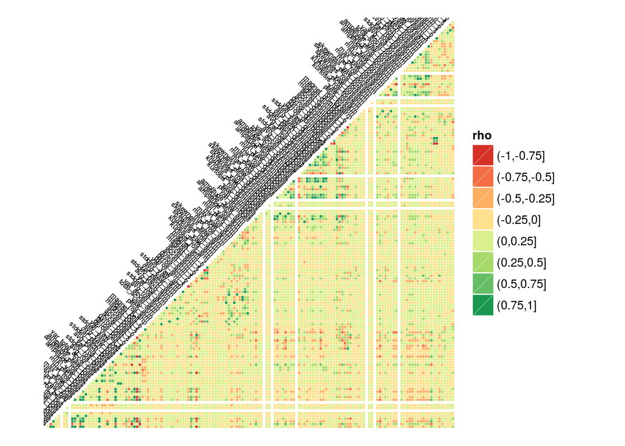

```r
library(ggplot2)
library(GGally)

ggcorr(weights.training[,7:158], angle=-45, hjust=1.05, size=2)
```

Notice that we have quite a few variables that seem to contain mostly missing values. These will prove problematic for prediction purposes. Indeed, let’s remove all variables that consist mostly of missing values. Also notice that there are a number of highly correlated variables as well, which we will deal with below.

```r
weights.training <- weights.training %>%
    select(which(sapply(1:159, function(i) sum(is.na(weights.training[,i]))) <= nrow(weights.training) / 2))
```

This has reduced the data from 159 variables to 59.

Next, we want to make sure that we remove any metadata that will be strongly correlated to our response variable but that isn’t necessarily a part of what we wish to model. We have already removed one such variable (X, the line number), but notice that time is another variable strongly correlated to our response variable:

```r
table(weights.training$cvtd_timestamp, weights.training$classe)
```

```
##
##                      A   B   C   D   E
##   02/12/2011 13:32 123   0   0   0   0
##   02/12/2011 13:33 657 210   0   0   0
##   02/12/2011 13:34   0 306 486 127   0
##   02/12/2011 13:35   0   0   0 220 471
##   02/12/2011 14:56 152   0   0   0   0
##   02/12/2011 14:57 436 455   0   0   0
##   02/12/2011 14:58   0  20 357 450  98
##   02/12/2011 14:59   0   0   0   0 385
##   05/12/2011 11:23 127   0   0   0   0
##   05/12/2011 11:24 415 472 106   0   0
##   05/12/2011 11:25   0   0 229 323 409
##   05/12/2011 14:22 181   0   0   0   0
##   05/12/2011 14:23 246 330 322   0   0
##   05/12/2011 14:24   0   0   6 302 325
##   28/11/2011 14:13 570   0   0   0   0
##   28/11/2011 14:14  19 422 326 250   0
##   28/11/2011 14:15   0   0   0 132 349
##   30/11/2011 17:10 596   0   0   0   0
##   30/11/2011 17:11 198 317 444   0   0
##   30/11/2011 17:12   0   0   6 340 368
```

We remove all time variables from our data set so us to not skew our predictor and make it appear more accurate than it would be with out-of-sample data.

```r
weights.training <- weights.training %>% select(-raw_timestamp_part_1, -raw_timestamp_part_2, -cvtd_timestamp)
```

This leaves our final training set at 13083 observations of 56 variables. As a sanity check to see how well we could predict some of these classes, we compare the frequency of each class to one another:

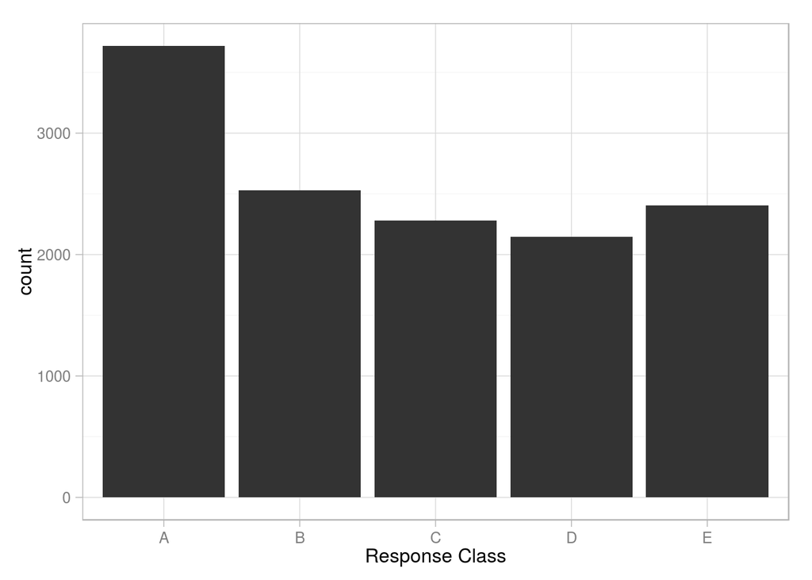

```r
frequency <- as.data.frame(table(weights.training$classe))
names(frequency) <- c("class", "count")
qplot(factor(class), count, data = frequency, geom="bar", stat="identity") + theme_light() +
    xlab("Response Class")
```

None of the classes are considerably smaller than any of the others, so we should not have low positive-predictive values for these classes.

## Model construction and training

The model is trained using 10-fold cross-validation repeated three times, set up using the following training control in the *caret* library:

```r
fitControl <- trainControl(method = "repeatedcv",
                           number = 10,
                           repeats = 3)
```

```r
modFit <- train(classe ~ ., method="treebag", data=weights.training,
                trControl = fitControl,
                preprocess="pca")
```

We obtain a good in-sample accuracy of 0.997 with low standard deviation:

```r
modFit
```

```
## Bagged CART
##
## 13083 samples
##    55 predictors
##     5 classes: 'A', 'B', 'C', 'D', 'E'
##
## No pre-processing
## Resampling: Cross-Validated (10 fold, repeated 3 times)
##
## Summary of sample sizes: 11776, 11774, 11774, 11775, 11774, 11775, ...
##
## Resampling results
##
##   Accuracy  Kappa   Accuracy SD  Kappa SD
##   0.9966    0.9957  0.001816     0.002297
##
##
```

Let us estimate the out-of-sample accuracy using the held-back testing sample:

```r
results <- predict(modFit, newdata=weights.testing)
confusion <- table(results, weights.testing$classe)
confusion
```

```
##
## results    A    B    C    D    E
##       A 1858    1    0    0    0
##       B    1 1259   11    0    0
##       C    0    3 1124    7    0
##       D    0    2    5 1065    7
##       E    1    0    0    0 1195
```

```r
accuracy <- sum(diag(confusion)) / sum(confusion)
accuracy
```

```
## [1] 0.9942
```

We estimate that our out-of-sample accuracy is 0.994.

## Conclusion

Using bootstrap aggregated decision trees we have achieved an in-sample accuracy of 0.997 and estimate our out-of-sample accuracy to be 0.994.